# Personal Spotify Data

This dataset is my personal spotify listening data, collected and provided by Spotify.

You can collect your own data from the following link: https://www.spotify.com/uk/account/privacy/

The notebook will provide the following insights:

```
- Most played songs over the past year.
- Most played songs within their respective months.
- My most frequent listening time.
```

```python
import pandas as pd
import numpy as np
import matplotlib.pyplot as plt
import seaborn as sns
import os
```

```python
dataset_dir = "/home/sam/Desktop/datasets/spotify/Spotify Account Data/"
```

```python
os.listdir(dataset_dir)
```

```
['Inferences.json',
 'FamilyPlan.json',
 'StreamingHistory_music_1.json',
 'Userdata.json',
 'Payments.json',
 'Follow.json',
 'SearchQueries.json',
 'StreamingHistory_podcast_0.json',
 'Identifiers.json',
 'Marquee.json',
 'YourLibrary.json',
 'Identity.json',
 'StreamingHistory.csv',
 'Playlist1.json',
 'DuoNewFamily.json',
 'StreamingHistory_audiobook_0.json',
 'Wrapped2023.json',
 'Read_Me_First.pdf',
 'StreamingHistory_music_0.json']
```

## Combining Data

We have two separate JSONs denoting the same content: `StreamingHistory_music_x.json`

These will be combined as they are separated by spotify at a row limit of 10,000.

```python
df_music_0 = pd.read_json(dataset_dir + "StreamingHistory_music_0.json")
df_music_1 = pd.read_json(dataset_dir + "StreamingHistory_music_1.json")
```

```python
df_music_joined = pd.concat([df_music_0, df_music_1])
# Commented out to avoid rewriting file.
# df_music_joined.to_csv(dataset_dir + "StreamingHistory.csv", index=False)
```

## Inspecting Data

```python
df = pd.read_csv(dataset_dir + "StreamingHistory.csv")
df.head(5)
```

|  | endTime | artistName | trackName | msPlayed |
| --- | --- | --- | --- | --- |
| 0 | 2023-09-02 14:37 | Daft Punk | Get Lucky (feat. Pharrell Williams and Nile Ro... | 41315 |
| 1 | 2023-09-02 15:15 | Wild Cherry | Play That Funky Music | 9200 |
| 2 | 2023-09-02 22:33 | Fort Minor | Remember the Name (feat. Styles of Beyond) | 17712 |
| 3 | 2023-09-02 22:35 | Caribou | Can't Do Without You | 109936 |
| 4 | 2023-09-02 22:36 | Barry Can't Swim | Rah That's A Mad Question | 58586 |

```python
df.isna().sum()
```

```
endTime       0
artistName    0
trackName     0
msPlayed      0
dtype: int64
```

```python
df[df["msPlayed"] == 0].head(5)
```

|  | endTime | artistName | trackName | msPlayed |
| --- | --- | --- | --- | --- |
| 16 | 2023-09-04 08:48 | Post Malone | Something Real | 0 |
| 173 | 2023-09-07 19:04 | Olivier St.Louis | Runnin' Wild | 0 |
| 451 | 2023-09-13 13:15 | Post Malone | Landmine | 0 |
| 533 | 2023-09-14 13:04 | J. Cole | No Role Modelz | 0 |
| 568 | 2023-09-14 15:47 | Kanye West | Diamonds From Sierra Leone | 0 |

### Notes on the Data

As we view the data, we note a few things:

```
- It is time sensitive, we have timestamps of listening.
- Each play of a song is not necessarily the whole song. (See Play that Funky Music by Wild Cherry, second row).
- The data starts in September 2023 and ends in August 2024.
- There are no null values but there are songs with 0 playtime (presumably immediately skipped on a playlist).
```

### Unfinished Songs

While we have each song's playtime, we do not have the max playtime for a song.

For example, we listened to `Play that Funky Music` for 9.2s, but we do not **know** if that is the whole song. It is obvious for this case but we do not know when it is less obvious.

We could group the songs by trackName and find the max msPlayed. This is not fullproof as if we have only played `Play that Funky Music` once, then the max msPlayed is 9200. Furthermore, this may filter out plays where we skip in the final few seconds.

A publication by Paul Lamere, https://musicmachinery.com/2014/05/02/the-skip/, shows that songs on Spotify have a 35.05% likelihood of being skipped in the first 30 seconds and 48.60% of being skipped before the song ends.

From this, we can conclude that 72.12% of skipped songs are skipped in the first 30 seconds. Let's count all songs less than 30 seconds and see how many we have in our dataset.

```python
short_plays = df[df['msPlayed'] < 30000].shape[0]
total_plays = df.shape[0]

(short_plays / total_plays) * 100
```

```
37.477055509842394
```

### Unfinished Songs Conclusion

We see that 37.48% of our plays are less than 30 seconds, which closely corresponds to the 35.05% likelihood of being skipped. From this conclusion, we can make the assumption that our plays of less than 30 seconds are skips.

```python
df_min_playtime = df[df["msPlayed"] > 30000]
```

## Most Played Songs

```python
most_played_songs = df_min_playtime.groupby("trackName").size().sort_values(ascending=False)[:20]
```

```python
x_axis = np.array(most_played_songs)
y_axis = np.array(most_played_songs.keys())
```

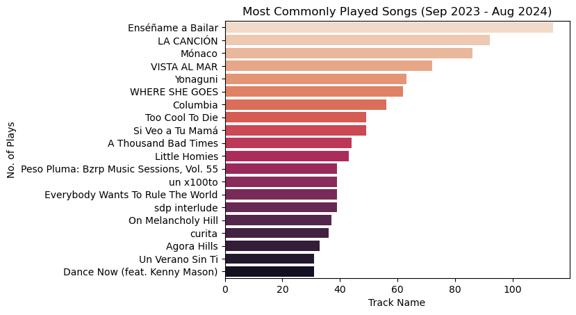

```python
sns.barplot(x=x_axis, y=y_axis, palette="rocket_r")
plt.title("Most Commonly Played Songs (Sep 2023 - Aug 2024)")
plt.xlabel("Track Name")
plt.ylabel("No. of Plays")
```

## Most Played Songs of Each Month

The endTime is a column of a string object so we convert to a datetime object.

This allows us to group by month, or any other time segmentation.

```python
from datetime import datetime
```

```python
df_time = df_min_playtime.copy()
df_time.endTime = pd.to_datetime(df_min_playtime.endTime.str.strip(), format="%Y-%m-%d %H:%M")
```

```python
df_time["Month"] = df_time.endTime.dt.month
df_time["Year"] = df_time.endTime.dt.year
```

### Careful Grouping

The dataframe is grouped to obtain plays per month.

Consequently, we find the idxmax number of plays within each month (the index of the song with the most number of plays per month).

These indicies (one for each month) are used to index the series and we have our most played songs of each month.

#### Notable Change

Importantly, each grouping does not sort the values. The dataset starts in September 2023 and ends in August 2024. By sorting, and placing January at the top of the series, we imply that the listening starts at January.

The order of listening data tells a story, so it is important to recognise that as you process the data.

An obvious indicator of continued listening is that month 9 and month 10 have the same top song - clearly enjoying that song over an extended period.

```python
import calendar
```

```python
plays_per_month = df_time.groupby(["Month", "trackName"], sort=False)\
                    .size()\
                    .reset_index(name="Plays")

most_plays_per_month = plays_per_month.loc[plays_per_month.groupby("Month", sort=False)["Plays"].idxmax()]

most_plays_per_month["Month"] = most_plays_per_month["Month"].apply(lambda x : calendar.month_name[x])
most_plays_per_month
```

|  | Month | trackName | Plays |
| --- | --- | --- | --- |
| 272 | September | WHERE SHE GOES | 27 |
| 391 | October | WHERE SHE GOES | 14 |
| 946 | November | Ocean Prime (feat. Boldy James) | 14 |
| 1250 | December | Mónaco | 23 |
| 1439 | January | VISTA AL MAR | 17 |
| 1807 | February | Columbia | 27 |
| 2367 | March | Agora Hills | 16 |
| 3028 | April | LA CANCIÓN | 20 |
| 4152 | May | Enséñame a Bailar | 71 |
| 4644 | June | Enséñame a Bailar | 26 |
| 5247 | July | Texas Sun | 12 |
| 5309 | August | Enséñame a Bailar | 12 |

### Listening Insights

Well, it is clear that I have a thing for Hispanic music. In fact, if you make a quick adjustment (replace `trackName` for `artistName`) and you will see that Bad Bunny is the common artist amongst the months.

Furthermore, we see an a drastic increase in plays (for the top song) in May. This begs the question, do I listen to music more in May?

[figure not shown]

```python
total_plays_per_month = plays_per_month.groupby("Month", sort=False).size().reset_index(name="Plays")
total_plays_per_month["Month"] = total_plays_per_month["Month"].apply(lambda x: calendar.month_name[x])

sns.barplot(x=total_plays_per_month["Plays"], y=total_plays_per_month["Month"])
plt.title("No. of Plays per Month (Sep 2023 - Aug 2024)")
plt.xlabel("No. of Plays")

plt.axhline(3.5, linestyle='--', color='darkred')
plt.text(x=815, y=3.6, s='2024')

plt.show()
```

### Monthly Conclusions

However, the trend makes sense as the studying period approaches for my April/May exam season and I listen to music as I study. The songs even peter out as we head into June, outside of my studying season.

According to a survey by CSU Global, approximately 50% of students listen to music while studying so this is potentially a common trend - a further research question if there is global data available. (https://nypost.com/2022/08/18/students-who-listen-to-music-while-studying-have-a-higher-gpa-poll/)

## Most Frequent Listening Time

In this section, we aim to figure out at what time of the day I most commonly listen to music.

```python
# First of all, I extract the hours of the day and disregard the minutes, placing each song into a hour-long buckets.

df_hours = df_time.copy()
df_hours["Hour"] = df_hours.endTime.dt.hour
```

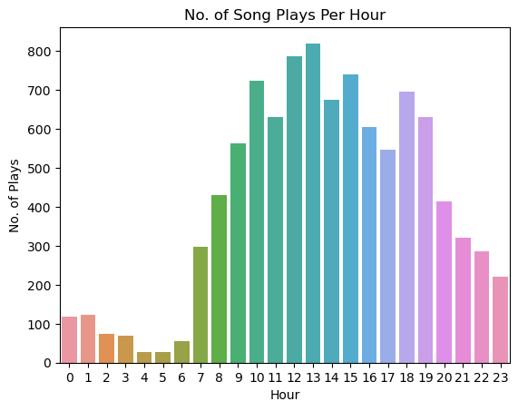

```python
## Group by hour and take the size.
plays_per_hour = df_hours.groupby("Hour", sort=True)\
                        .size()\
                        .reset_index(name="Plays")

sns.barplot(x=plays_per_hour["Hour"], y=plays_per_hour["Plays"])
plt.title("No. of Song Plays Per Hour")
plt.ylabel("No. of Plays")

plt.show()
```

### Listening Time - Insights

It is clear that I listen to the most music at 1pm, although it is not a large difference in the surrounding hours.

# Conclusion

Overall, we answered the information that we aimed to find.

We uncovered my top 20 most played songs, the most played songs amongst their respective months as well as our most frequent listening time.

The data was cleaned with some assumptions made with regards to skipped songs, which will have an impact on the results - most likely changing the scale as opposed to the trend.

We also recognised that my listening times, both daily and monthly, were influenced by my activties and major upcoming events, unsurprisingly.

Future steps:

```
- Obtain an augmenting song dataset, providing metadata about each of the songs, such as tempo and song length. This could allow some simple recommender systems and clustering.
- Look for Spotify listening data from multiple users, perhaps investigate relationship between monthly listening and exam season.
```